# Technical Challenge: HCC Survival Dataset

Hypothesis Testing

Author: Kim Phan

Created: 21-08-2019 | Updated: 12-09-2019

# Hypothesis

The predictive ability of clinical risk factors to identify survival among patients diagnosed with hepatocellular carcinoma (HCC) is improved with tumor staging and liver function assessments as well as with molecular biomarkers.

# Motivation

A number of approaches have been proposed to predict the prognosis for HCC, none of which are universally adopted.

Clinical risk factors including male sex, diabetes, and hepatitis B infection have been associated with poor survival rates. Scoring systems such as the Barcelona Clinic Liver Cancer system, endorsed by the European Association for the Study of the Liver and the American Association for the Study of Liver Diseases, incorporate the extent of the primary lesion, performance status, and liver function in prognostication. Additionally, new tumor molecular biomarkers are increasingly being incorporated into some classifications and represent promising tools for prognosis prediction.

Given the limited health care resources and the positive association between aggressive treatment and improvement of outcomes, better understanding the incremental predictive performance of these approaches will guide the development of the optimal screening guidelines.

# Analysis overview

1. Missing data was multiply imputed then split into a training and test dataset
2. Predictors in the data are separated into 1) clinical risk factors, 2) tumor staging/liver function parameters, and 3) molecular biomarkers
3. Within each “modality”, multivariable logistic regression models were identified via stepwise regression, best subsets, and an automated model selection and model averaging approach
4. The models were evaluated to identify multicollinearity, autocorrelation, and influential points
5. The best predictive model within each “modality” was selected based on predictive performance as assessed by receiver operating characteristic curves, accuracy, concordance, prevision (positive predictive value[PPV]), and negative predictive value. A high PPV was prioritized over NPV to minimize the rate at which patients would be incorrectly identified as surviving (which could prevent them from getting the appropriate care)
6. The models were compared in the training and test set as well as internally validated with 10-fold cross validation
7. Nomograms are shown to illustrate the post-test probability associated with the final predicive model

# Data setup

```r
# Load libraries
library(bestglm)
library(car)
library(caret)
library(corrplot)
library(cowplot)
library(dplyr)
library(ggplot2)
library(ggthemes)
library(glmnet)
library(glmulti)
library(Hmisc)
library(InformationValue)
library(LogisticDx)
library(MASS)
library(mice)
library(pROC)
library(randomForest)
library(scales)
library(tableone)
library(tidyr)


# Load data
rawData <- read.csv("./hcc-data.txt",
                    stringsAsFactors = FALSE,
                    na.string = "?",
                    header = FALSE)

seed <- 123
set.seed(seed)
sample_n(rawData, 5)
```

```
##     V1 V2 V3 V4 V5 V6 V7 V8 V9 V10 V11 V12 V13 V14 V15 V16 V17 V18 V19 V20
## 159  1 NA  0  0  0  0  0  1 NA  NA   1   0   0   0   1   0   0   1   1   1
## 14   1 NA  0  0  0  0  1  1 NA  NA   0   0   0   0   0   0   0   0   0   0
## 50   1 NA  1  0 NA  1  0  1  0   1   0   0   0   0   0   0   0   1   1   1
## 118  1  1  1  1  1  1  0  1  0  NA   0   0   0   0   0   0   0  NA   1   1
## 43   0  0  1  0  0  0  0  1 NA  NA   0   0   0   0   0   0   0  NA   0   0
##     V21 V22 V23 V24 V25 V26 V27 V28 V29  V30      V31  V32   V33 V34
## 159   0   0   1  71   0  NA   3   1   1 1.16   1713.0  8.2  94.2 6.0
## 14    0   0   1  56   0  NA   0   1   1 1.20      6.6 13.7  93.8 4.1
## 50    0   0   0  58  NA  40   0   1   1 1.49     20.0 15.0  96.7 9.0
## 118   0   0   0  63 120  NA   4   3   2 2.42  22475.0 12.0 111.4 9.9
## 43    0   1   0  86  NA  NA   3   1   1 1.20 185203.0 15.0  85.5 8.8
##        V35  V36  V37 V38 V39 V40 V41 V42  V43 V44  V45 V46 V47 V48  V49
## 159 209000 3.60  0.3  62  59 450 263 6.8 1.49   1  7.5  NA  NA  NA   NA
## 14   91000 4.50  1.0 103  96 205  70 8.8 0.88   1 22.0  NA  82  24   NA
## 50      78 4.60  2.1  40  49 137 109 7.6 0.80   1  2.0 0.4 184  59  905
## 118  70000 3.28 19.0 134 178  54 146 8.0 3.23   1   NA 9.7 106  67 2165
## 43     183 3.60  1.0  49 117 442 278 7.2 0.86   5 15.8 0.3  21   9  279
##     V50
## 159   1
## 14    1
## 50    1
## 118   0
## 43    0
```

```r
# Rename columns
names(rawData) <- c("male", "symptoms", "alcohol",
                    "hepBsAg", "hepBeAg", "hepBcAb", "hepCvAb",
                    "cirrhosis", "endemic", "smoking", "diabetes", "obesity",
                    "hemochromatosis", "hypertension", "renalInsufficiency", "hiv",
                    "nash", "varices", "splenomegaly", "portalHypertension", "pvt",
                    "metastasis", "hallmark",
                    "age",
                    "alcohol_g", "smoking_pack",
                    "performance", "encephalopathy", "ascites",
                    "inr", "afp", "hb", "mcv", "leuk", "plt", "albumin",
                    "bilirubin_total", "alt", "ast", "ggt", "alp", "protein_total",
                    "creatinine",
                    "nodule_no",
                    "nodule_dim", "bilirubin_direct", "iron", "o2sat", "ferritin",
                    "lives")

# Set variable data types
data <- rawData %>%
    mutate_all(as.numeric) %>%
    mutate_at(vars(male:hallmark, nodule_no), as.factor) %>%
    mutate_at(vars(age), as.integer) %>%
    mutate(performance = factor(performance, levels = c(0, 1, 2, 3, 4), ordered = TRUE),
           encephalopathy = factor(encephalopathy, levels = c(1, 2, 3), ordered = TRUE),
           ascites = factor(ascites, levels = c(1, 2, 3), ordered = TRUE)) %>%
    mutate_at(vars(lives), as.factor)

str(data)
```

```
## 'data.frame':    165 obs. of  50 variables:
##  $ male              : Factor w/ 2 levels "0","1": 2 1 2 2 2 2 2 2 2 2 ...
##  $ symptoms          : Factor w/ 2 levels "0","1": 1 NA 1 2 2 1 1 2 2 2 ...
##  $ alcohol           : Factor w/ 2 levels "0","1": 2 1 2 2 2 2 1 2 2 2 ...
##  $ hepBsAg           : Factor w/ 2 levels "0","1": 1 1 2 1 2 1 1 1 1 1 ...
##  $ hepBeAg           : Factor w/ 2 levels "0","1": 1 1 1 1 1 NA NA NA 1 1 ...
##  $ hepBcAb           : Factor w/ 2 levels "0","1": 1 1 2 1 2 1 2 1 1 1 ...
##  $ hepCvAb           : Factor w/ 2 levels "0","1": 1 2 1 1 1 1 2 1 1 1 ...
##  $ cirrhosis         : Factor w/ 2 levels "0","1": 2 2 2 2 2 2 2 2 2 2 ...
##  $ endemic           : Factor w/ 2 levels "0","1": 1 NA 1 1 1 1 1 1 1 1 ...
##  $ smoking           : Factor w/ 2 levels "0","1": 2 NA 2 2 2 NA 1 2 2 1 ...
##  $ diabetes          : Factor w/ 2 levels "0","1": 2 2 1 2 1 1 2 2 2 1 ...
##  $ obesity           : Factor w/ 2 levels "0","1": NA 1 1 1 1 2 1 NA 1 1 ...
##  $ hemochromatosis   : Factor w/ 2 levels "0","1": 2 1 1 1 1 1 NA 1 1 2 ...
##  $ hypertension      : Factor w/ 2 levels "0","1": 1 2 2 2 2 1 1 1 2 1 ...
```

[output cut: 36 more lines]

# Missing data imputation

### Survey extent of missing data

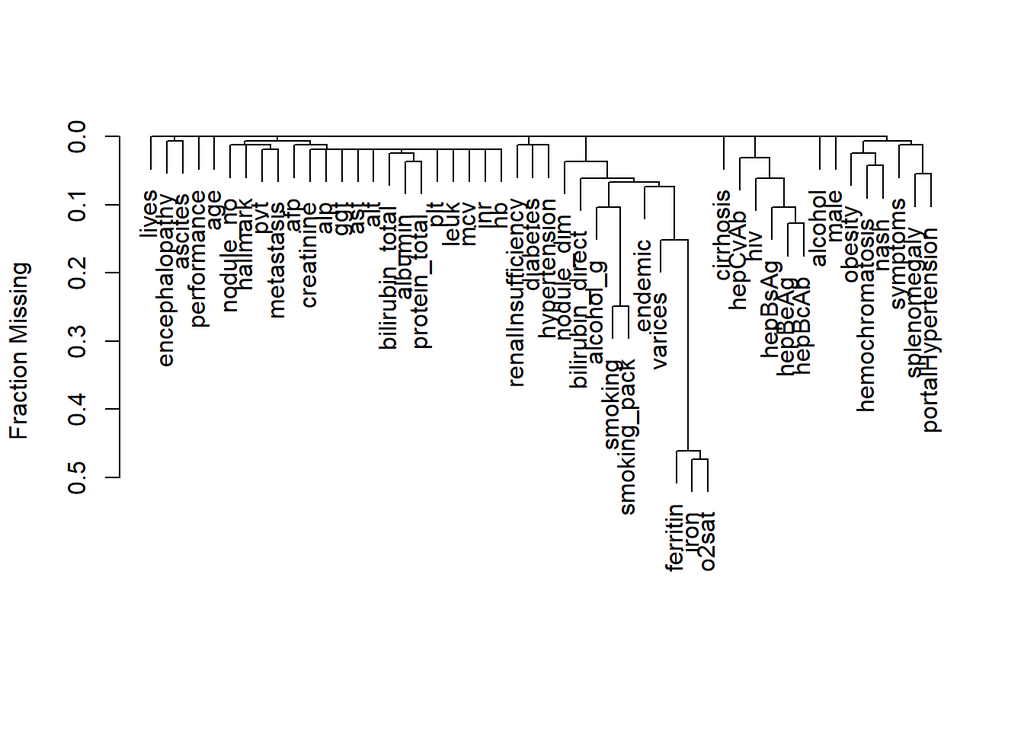

```r
na.patterns <- naclus(data)  # hierarchical cluster of NA
plot(na.patterns)
```

```r
featureMissing <- apply(data, 2, function(x) sum(is.na(x))/length(x))
featureMissing[featureMissing > 0.25]  # vars with > 25% missing data
```

```
##          varices        alcohol_g     smoking_pack bilirubin_direct
##        0.3151515        0.2909091        0.3212121        0.2666667
##             iron            o2sat         ferritin
##        0.4787879        0.4848485        0.4848485
```

```r
data.slimF <- data %>%
    dplyr::select(-c(varices, alcohol_g, smoking_pack, bilirubin_direct,
                     iron, o2sat, ferritin))
```

- “varices”, “alcohol_g”, “smoking_pack”, “bilirubin_direct”, “iron”, “o2sat”, and “ferritin” all have >25% missing data and are removed

```r
obsMissing <- apply(data.slimF, 1, function(x) sum(is.na(x))/length(x))
obsMissing[obsMissing > 0.25]  # obs with > 25% missing data
```

```
## [1] 0.3953488 0.4418605 0.3255814
```

```r
drop <- which(obsMissing > 0.25)
data.slimFO <-  data.slimF %>%
    slice(-drop)
```

- 3 patients had >25% data missing and are also removed

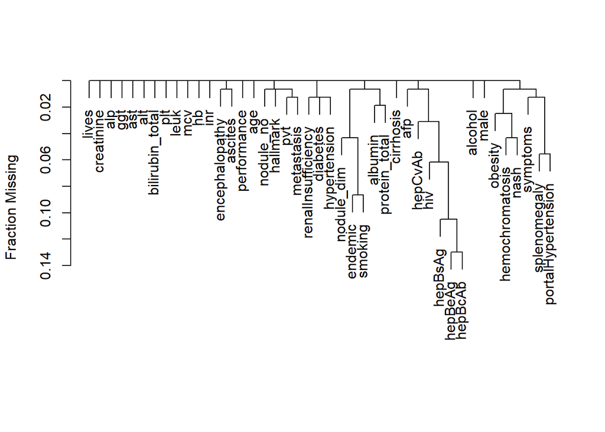

```r
na.patterns <- naclus(data.slimFO)
plot(na.patterns)
```

### Multiple imputation by fully conditional specification

```r
ghost.imp <- mice(data = data.slimFO, maxit = 0, print = FALSE)
pred <- quickpred(data.slimFO, mincor = 0.35, minpuc = 0.35)

toImpute <- names(data.slimFO)[apply(data.slimFO,
                                     2,
                                     function(x) sum(is.na(x))/length(x)) > 0]
pred_modified <- pred
pred_modified[toImpute, "lives"] <- 1

data.mids <- mice(data.slimFO, m = 5, maxit = 50, printFlag = FALSE,
                  seed = seed,
                  predictorMatrix = pred_modified)
data.imp <- mice::complete(data.mids)
```

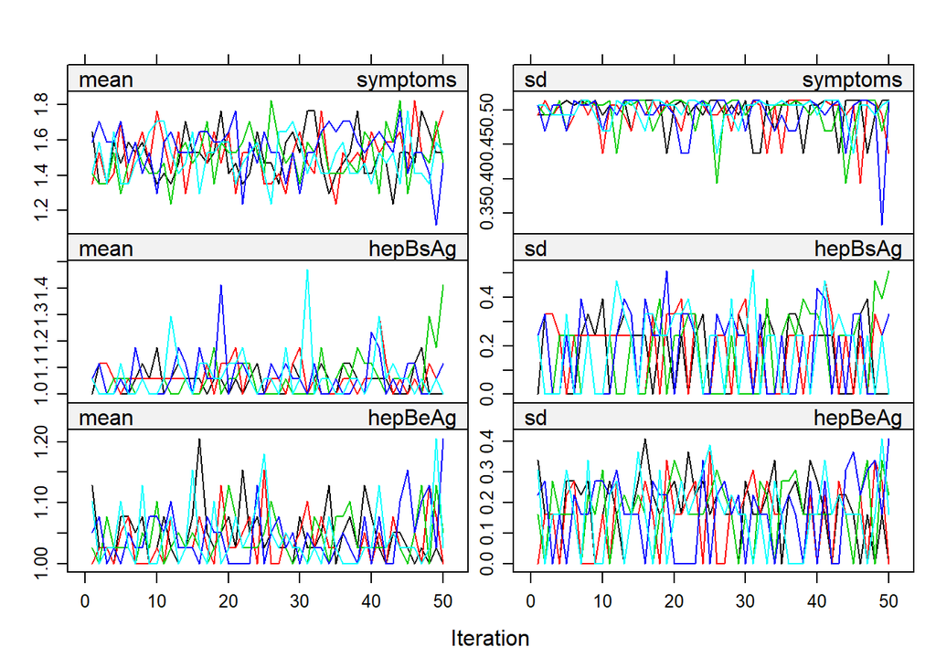

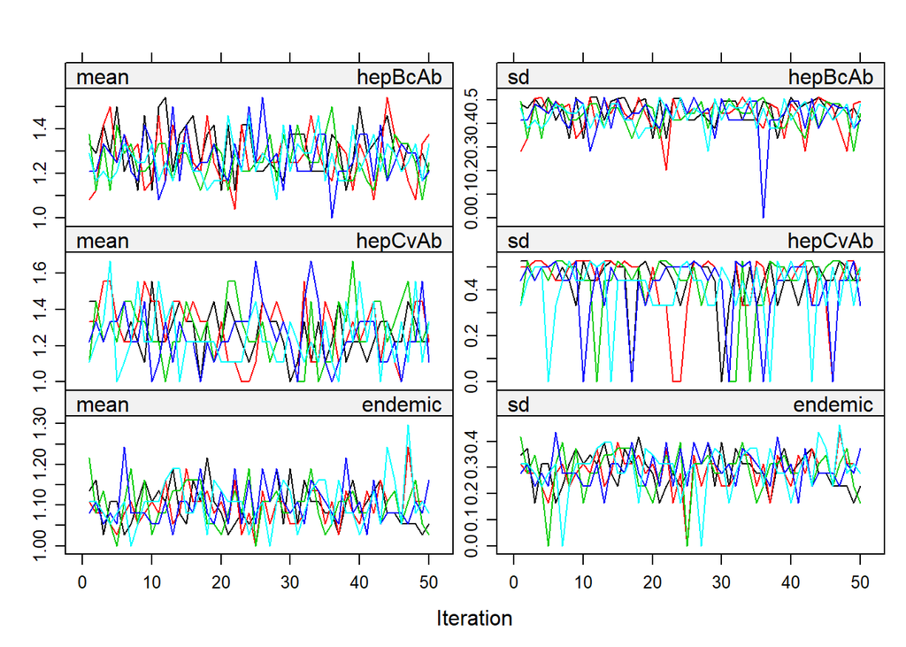

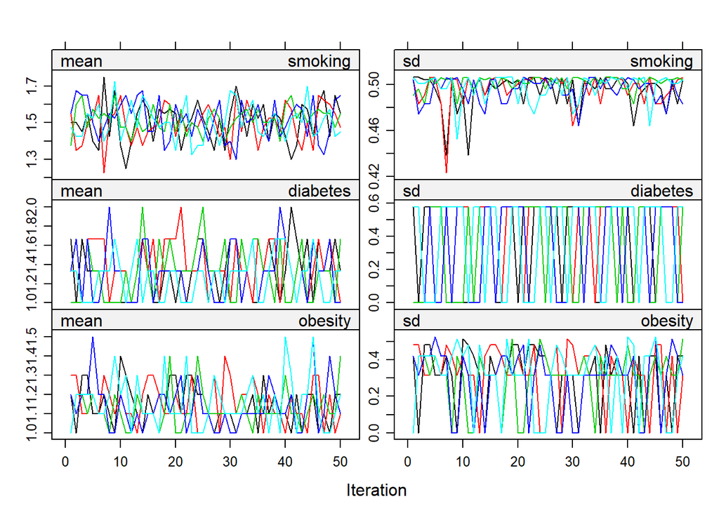

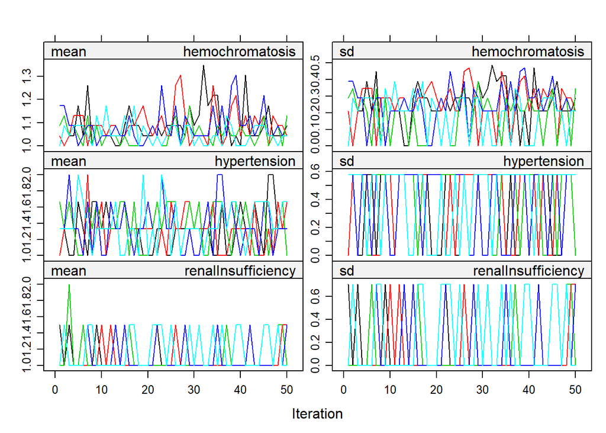

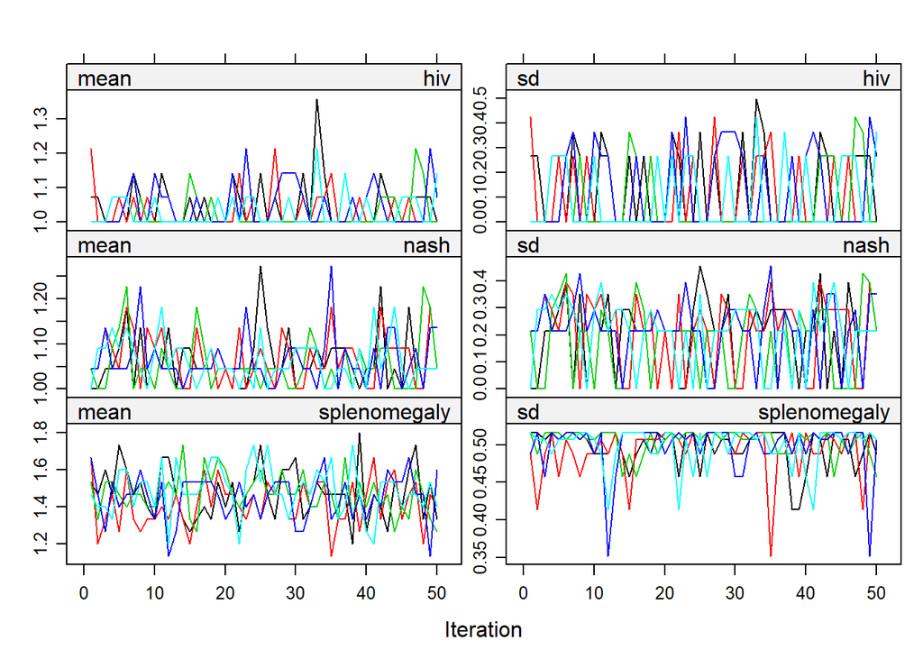

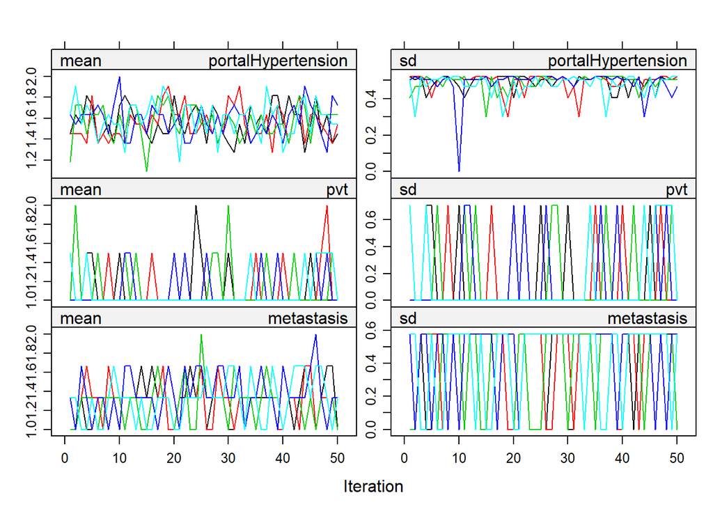

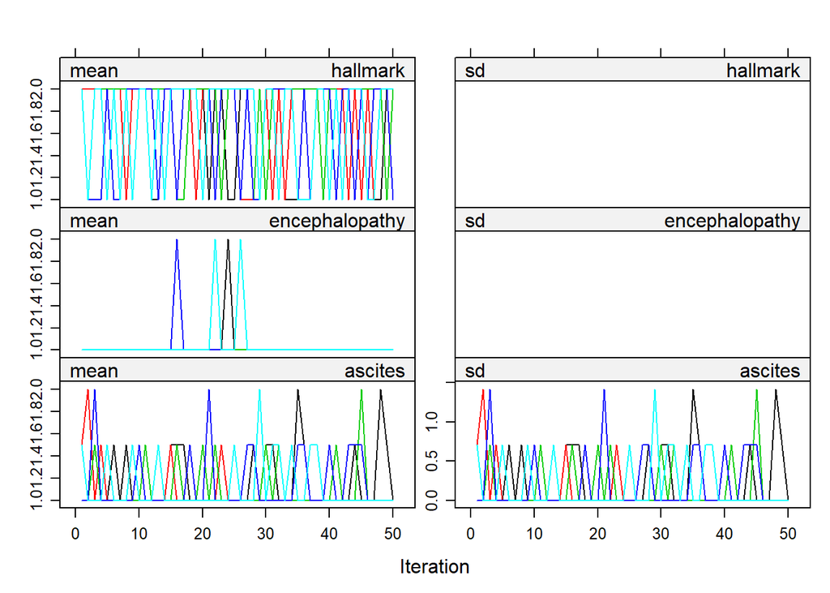

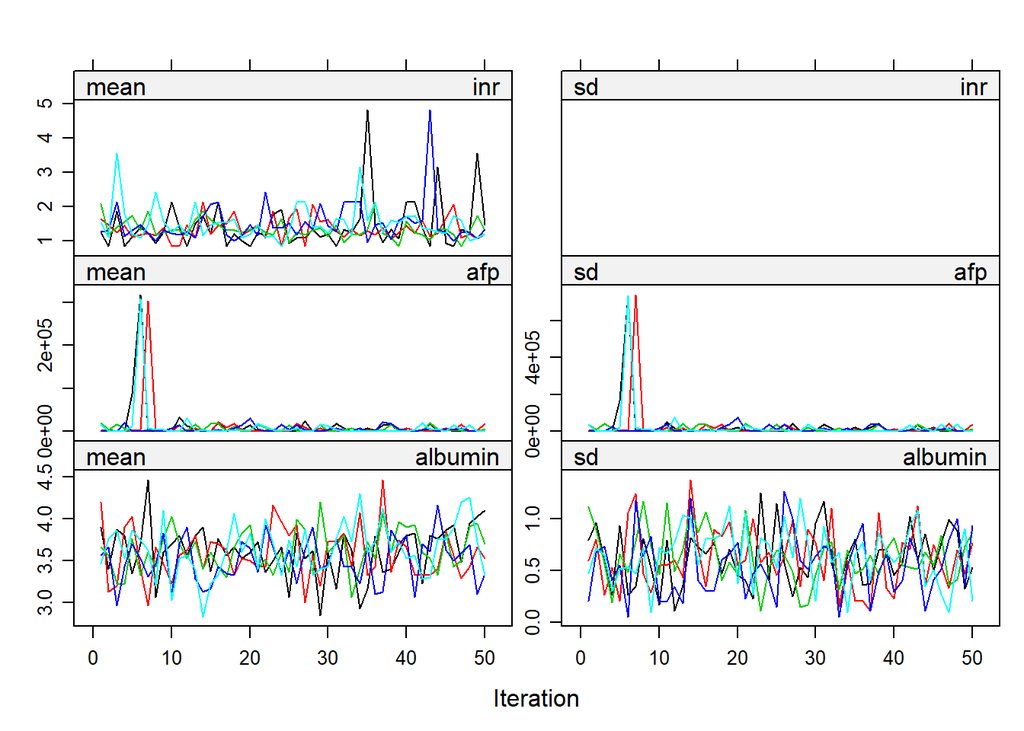

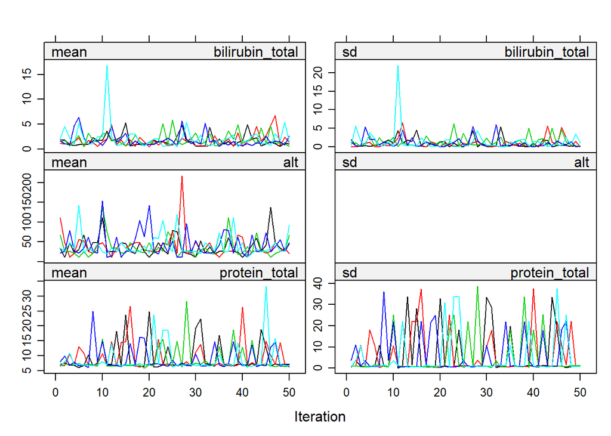

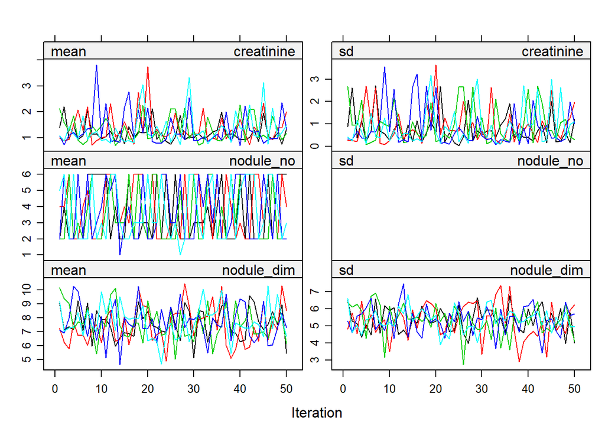

```r
# Check convergence over iterations
plot(data.mids)
```

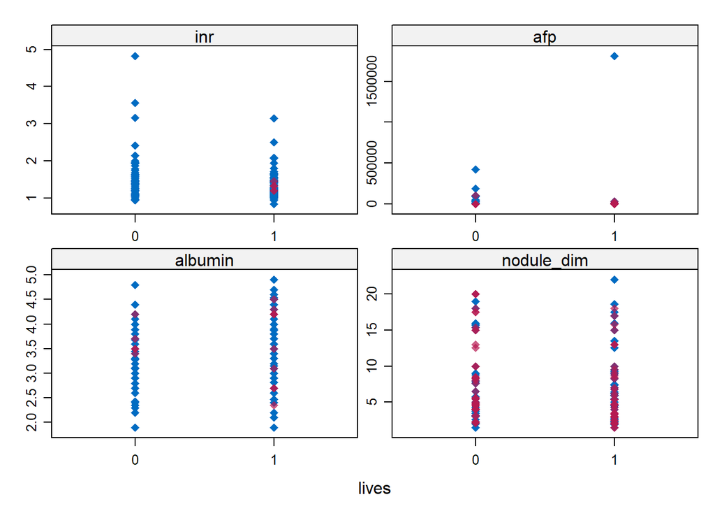

```r
# Check imputed values in continuous variables
xyplot(data.mids, inr + afp + albumin + nodule_dim ~ lives, pch = 18, cex = 1)
```

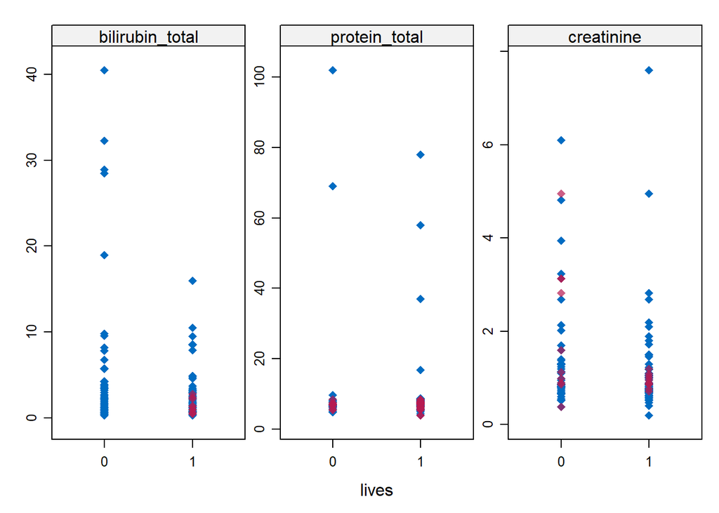

```r
xyplot(data.mids, bilirubin_total + protein_total + creatinine ~ lives, pch = 18, cex = 1)
```

- The streams intermingle without any clear trend so the algorithm converged
- The imputations are consistent with observed values

# Quick exploratory data analysis

**Note**: see “eda.ipynb” for more complete EDA with original dataset (without imputed values)

### Take a peek at the data

```r
# Peek at the data
contents(data.imp)
```

```
##
## Data frame:data.imp  162 observations and 43 variables    Maximum # NAs:0
##
##
##                    Levels   Class Storage
## male                    2         integer
## symptoms                2         integer
## alcohol                 2         integer
## hepBsAg                 2         integer
## hepBeAg                 2         integer
## hepBcAb                 2         integer
## hepCvAb                 2         integer
## cirrhosis               2         integer
## endemic                 2         integer
## smoking                 2         integer
## diabetes                2         integer
## obesity                 2         integer
## hemochromatosis         2         integer
## hypertension            2         integer
## renalInsufficiency      2         integer
## hiv                     2         integer
## nash                    2         integer
## splenomegaly            2         integer
## portalHypertension      2         integer
## pvt                     2         integer
## metastasis              2         integer
## hallmark                2         integer
## age                               integer
## performance             5 ordered integer
## encephalopathy          3 ordered integer
## ascites                 3 ordered integer
## inr                                double
## afp                                double
## hb                                 double
## mcv                                double
## leuk                               double
## plt                                double
## albumin                            double
## bilirubin_total                    double
## alt                                double
```

[output cut: 28 more lines]

```
## |nash              |           |
## |splenomegaly      |           |
## |portalHypertension|           |
## |pvt               |           |
## |metastasis        |           |
## |hallmark          |           |
## |lives             |           |
## +------------------+-----------+
## |performance       |0,1,2,3,4  |
## +------------------+-----------+
## |encephalopathy    |1,2,3      |
## |ascites           |           |
## +------------------+-----------+
## |nodule_no         |0,1,2,3,4,5|
## +------------------+-----------+
```

```r
describe(data.imp)
```

```
## data.imp
##
##  43  Variables      162  Observations
## ---------------------------------------------------------------------------
## male
##        n  missing distinct
##      162        0        2
##
## Value          0     1
## Frequency     29   133
## Proportion 0.179 0.821
## ---------------------------------------------------------------------------
## symptoms
##        n  missing distinct
##      162        0        2
##
## Value          0     1
## Frequency     61   101
## Proportion 0.377 0.623
## ---------------------------------------------------------------------------
## alcohol
##        n  missing distinct
##      162        0        2
##
## Value          0     1
## Frequency     40   122
## Proportion 0.247 0.753
## ---------------------------------------------------------------------------
## hepBsAg
##        n  missing distinct
##      162        0        2
##
## Value          0     1
## Frequency    146    16
## Proportion 0.901 0.099
## ---------------------------------------------------------------------------
## hepBeAg
##        n  missing distinct
##      162        0        2
##
```

[output cut: 297 more lines]

```
##        n  missing distinct     Info     Mean      Gmd      .05      .10
##      162        0       66    0.999    6.722    5.289     2.00     2.10
##      .25      .50      .75      .90      .95
##     3.00     4.90     8.95    15.00    17.47
##
## lowest :  1.5  1.9  2.0  2.1  2.2, highest: 18.0 18.6 19.0 20.0 22.0
## ---------------------------------------------------------------------------
## lives
##        n  missing distinct
##      162        0        2
##
## Value          0     1
## Frequency     63    99
## Proportion 0.389 0.611
## ---------------------------------------------------------------------------
```

```r
# Survival rate
table(data.imp$lives)
```

```
##
##  0  1
## 63 99
```

```r
prop.table(table(data.imp$lives))
```

```
##
##         0         1
## 0.3888889 0.6111111
```

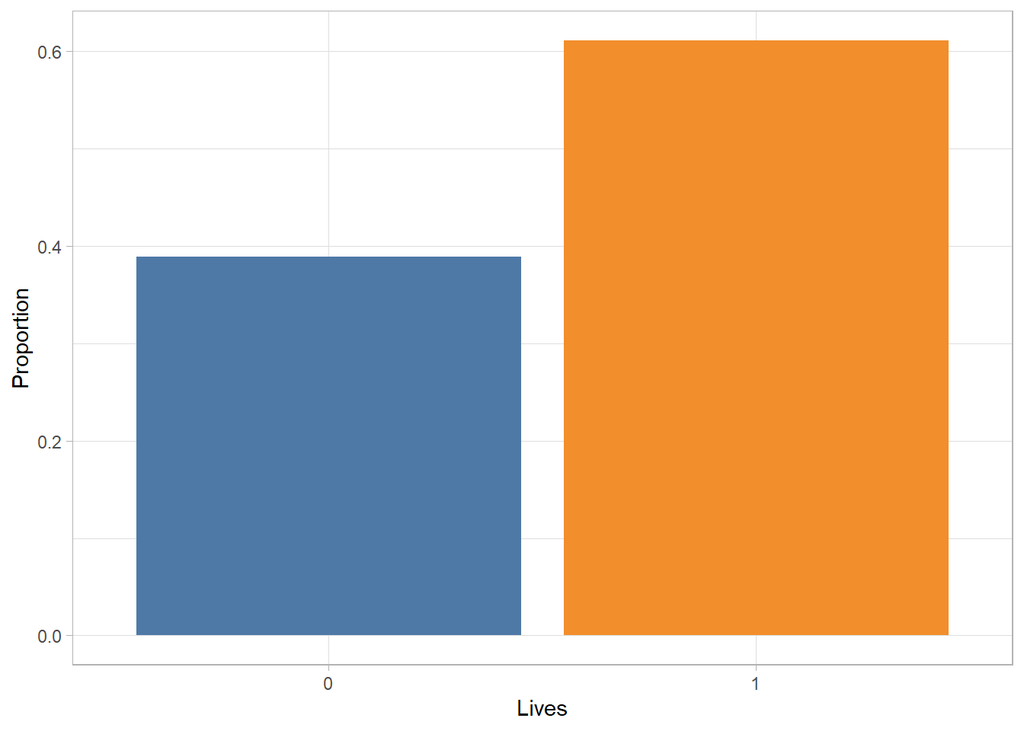

```r
ggplot(data.imp, aes(lives)) +
    geom_bar(aes(y = (..count..)/sum(..count..), fill = lives)) +
    theme_light() +
    theme(legend.position = "nobe") +
    ggthemes::scale_fill_tableau(name = "Lives") +
    labs(x = "Lives",
         y = "Proportion")
```

- 99 (61.1%) of the population lives

### Univariate plots of predictors and comparison between those who did and did not live

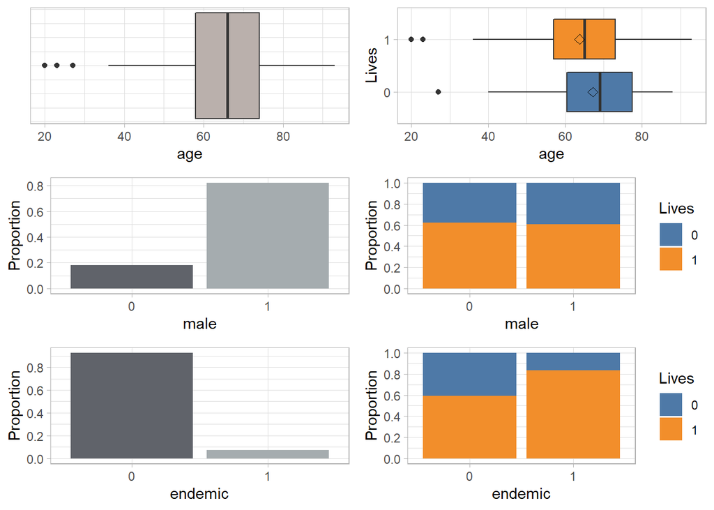

```r
varsPred <- names(data.imp)[-which(names(data.imp) == "lives")]
plots.univar <- list()
plots.bivar <- list()

for (i in seq_along(varsPred)) {  # create distribution plots
    if (is.numeric(data.imp[, varsPred[i]])) {  # coninuous variables
        plots.univar[[varsPred[i]]] <- ggplot(data.imp, aes_string(y = varsPred[i])) +
            geom_boxplot(fill = "#BAB0AC") +
            coord_flip() +
            theme_light() +
            theme(axis.text.y = element_blank(),
                  axis.ticks.y = element_blank()) +
            labs(x = "",
                 y = varsPred[i])
        plots.bivar[[varsPred[i]]] <- ggplot(data.imp, aes_string(x = "lives", y = varsPred[i],
                                                                  group = "lives", fill = "lives")) +
            geom_boxplot() +
            coord_flip() +
            stat_summary(fun.y = mean, geom = "point",
                         shape = 5, size = 2, color = "black") +
            theme_light() +
            theme(legend.position = "none") +
            ggthemes::scale_fill_tableau() +
            labs(x = "Lives",
                 y = varsPred[i])
    } else {  # categorical variables
        plots.univar[[varsPred[i]]] <- ggplot(data.imp, aes_string(x = varsPred[i])) +
            geom_bar(aes(y = ..prop.., group = 1, fill = factor(..x..))) +
            scale_y_continuous(breaks = seq(0, 1, by = 0.2)) +
            theme_light() +
            theme(legend.position = "none") +
            ggthemes::scale_fill_tableau(palette = "Classic Gray 5") +
            labs(y = "Proportion",
                 x = varsPred[i])
        plots.bivar[[varsPred[i]]] <- ggplot(data.imp, aes_string(x = varsPred[i],
                                                                  fill = "lives")) +
            geom_bar(position = "fill") +
            scale_y_continuous(breaks = seq(0, 1, by = 0.2)) +
            theme_light() +
            ggthemes::scale_fill_tableau(name = "Lives") +
            labs(y = "Proportion",
                 x = varsPred[i])
    }
}

# Plot clinical risk factors
cowplot::plot_grid(plots.univar[["age"]], plots.bivar[["age"]],
                   plots.univar[["male"]], plots.bivar[["male"]],
                   plots.univar[["endemic"]], plots.bivar[["endemic"]],
                   ncol = 2, axis = "tb", align = "v")
```

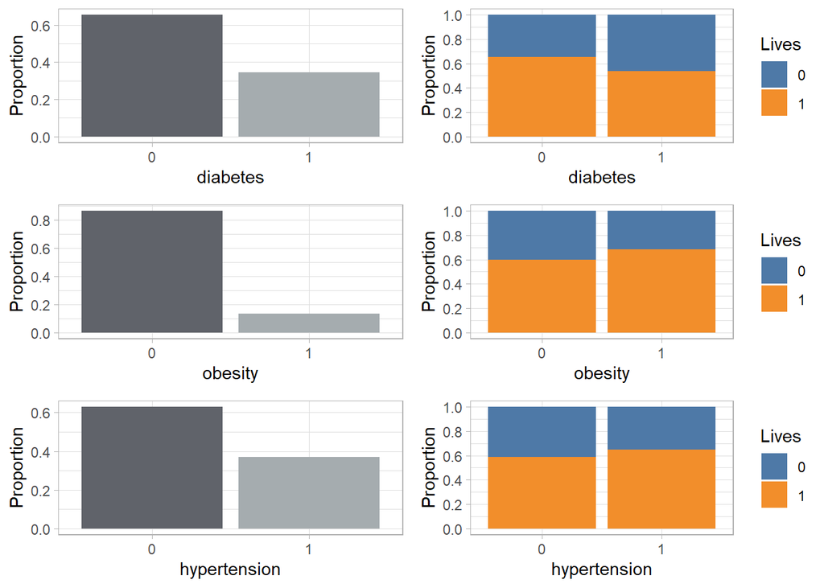

```r
cowplot::plot_grid(plots.univar[["diabetes"]], plots.bivar[["diabetes"]],
                   plots.univar[["obesity"]], plots.bivar[["obesity"]],
                   plots.univar[["hypertension"]], plots.bivar[["hypertension"]],
                   ncol = 2, axis = "tb", align = "v")
```

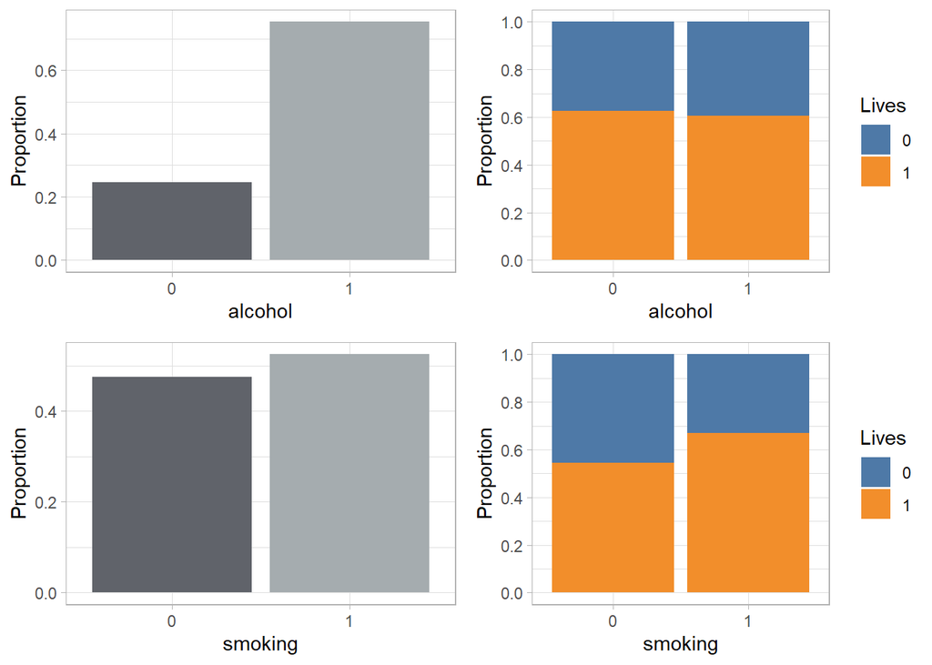

```r
cowplot::plot_grid(plots.univar[["alcohol"]], plots.bivar[["alcohol"]],
                   plots.univar[["smoking"]], plots.bivar[["smoking"]],
                   ncol = 2, axis = "tb", align = "v")
```

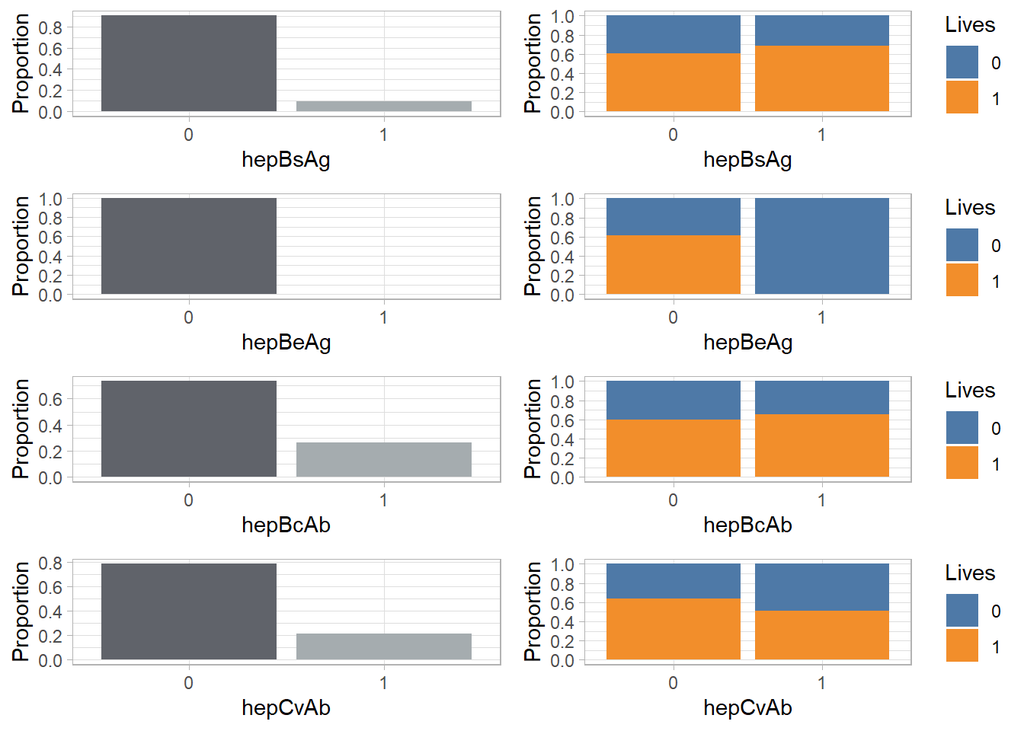

```r
cowplot::plot_grid(plots.univar[["hepBsAg"]], plots.bivar[["hepBsAg"]],
                   plots.univar[["hepBeAg"]], plots.bivar[["hepBeAg"]],
                   plots.univar[["hepBcAb"]], plots.bivar[["hepBcAb"]],
                   plots.univar[["hepCvAb"]], plots.bivar[["hepCvAb"]],
                   ncol = 2, axis = "tb", align = "v")
```

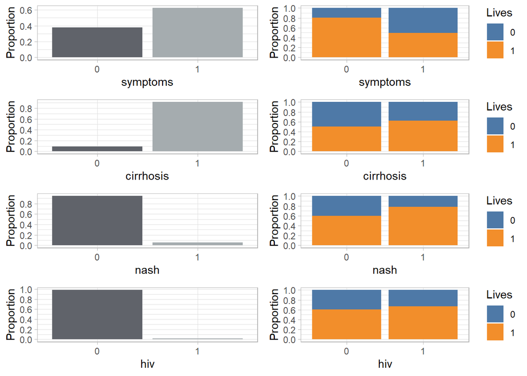

```r
cowplot::plot_grid(plots.univar[["symptoms"]], plots.bivar[["symptoms"]],
                   plots.univar[["cirrhosis"]], plots.bivar[["cirrhosis"]],
                   plots.univar[["nash"]], plots.bivar[["nash"]],
                   plots.univar[["hiv"]], plots.bivar[["hiv"]],
                   ncol = 2, axis = "tb", align = "v")
```

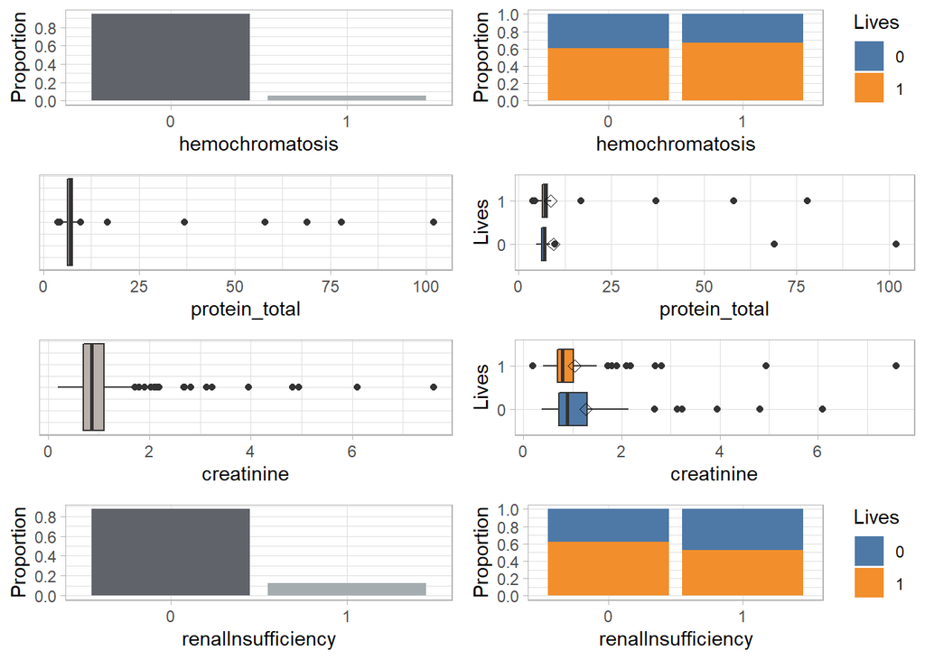

```r
cowplot::plot_grid(plots.univar[["hemochromatosis"]], plots.bivar[["hemochromatosis"]],
                   plots.univar[["protein_total"]], plots.bivar[["protein_total"]],
                   plots.univar[["creatinine"]], plots.bivar[["creatinine"]],
                   plots.univar[["renalInsufficiency"]], plots.bivar[["renalInsufficiency"]],
                   ncol = 2, axis = "tb", align = "v")
```

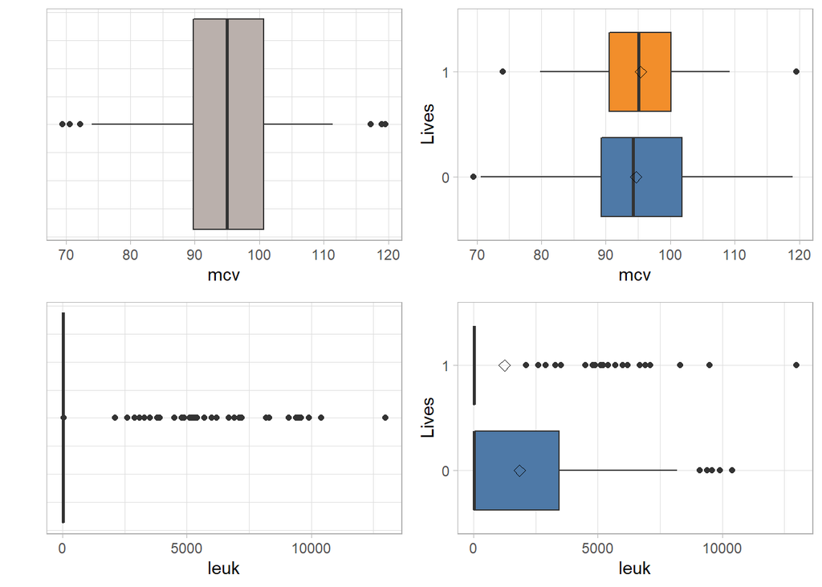

```r
cowplot::plot_grid(plots.univar[["mcv"]], plots.bivar[["mcv"]],
                   plots.univar[["leuk"]], plots.bivar[["leuk"]],
                   ncol = 2, axis = "tb", align = "v")
```

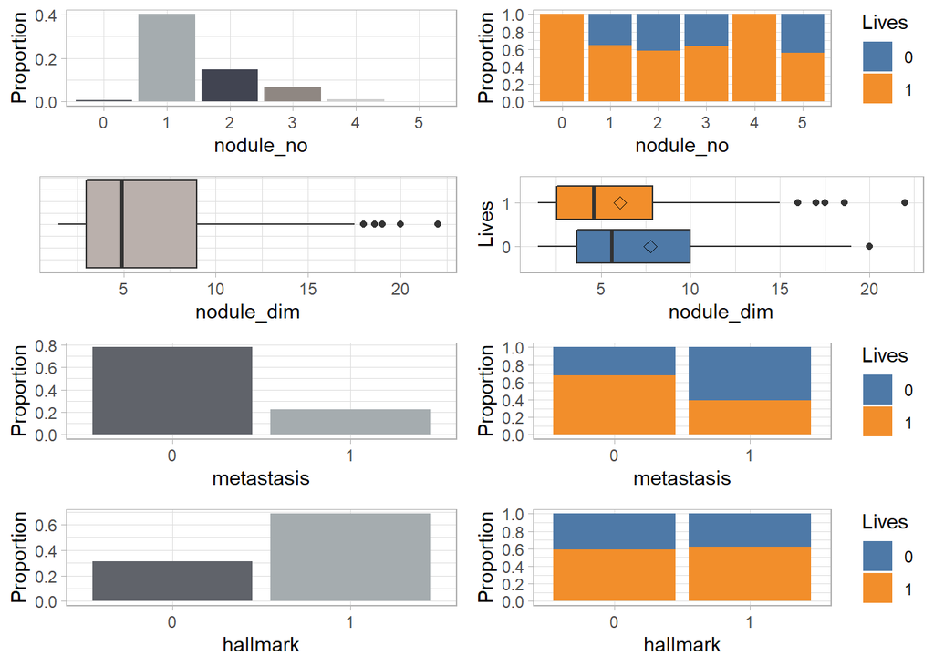

```r
# Plot tumor status markers
cowplot::plot_grid(plots.univar[["nodule_no"]], plots.bivar[["nodule_no"]],
                   plots.univar[["nodule_dim"]], plots.bivar[["nodule_dim"]],
                   plots.univar[["metastasis"]], plots.bivar[["metastasis"]],
                   plots.univar[["hallmark"]], plots.bivar[["hallmark"]],
                   ncol = 2, axis = "tb", align = "v")
```

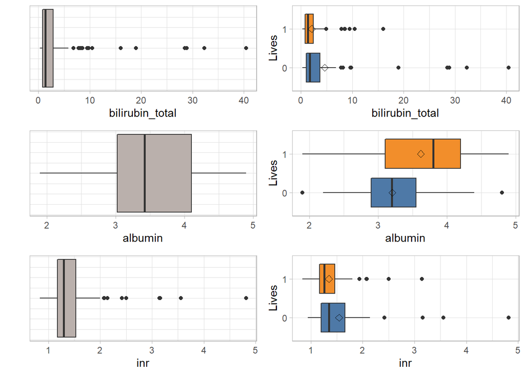

```r
# Plot liver function markers
cowplot::plot_grid(plots.univar[["bilirubin_total"]], plots.bivar[["bilirubin_total"]],
                   plots.univar[["albumin"]], plots.bivar[["albumin"]],
                   plots.univar[["inr"]], plots.bivar[["inr"]],
                   ncol = 2, axis = "tb", align = "v")
```

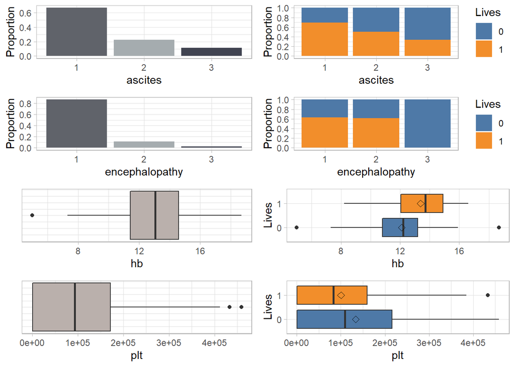

```r
cowplot::plot_grid(plots.univar[["ascites"]], plots.bivar[["ascites"]],
                   plots.univar[["encephalopathy"]], plots.bivar[["encephalopathy"]],
                   plots.univar[["hb"]], plots.bivar[["hb"]],
                   plots.univar[["plt"]], plots.bivar[["plt"]],
                   ncol = 2, axis = "tb", align = "v")
```

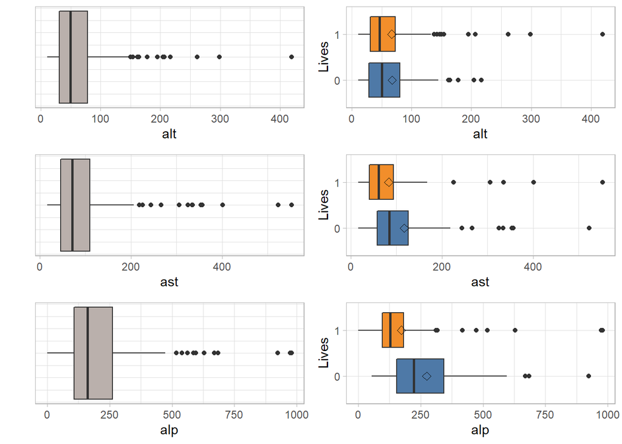

```r
cowplot::plot_grid(plots.univar[["alt"]], plots.bivar[["alt"]],
                   plots.univar[["ast"]], plots.bivar[["ast"]],
                   plots.univar[["alp"]], plots.bivar[["alp"]],
                   ncol = 2, axis = "tb", align = "v")
```

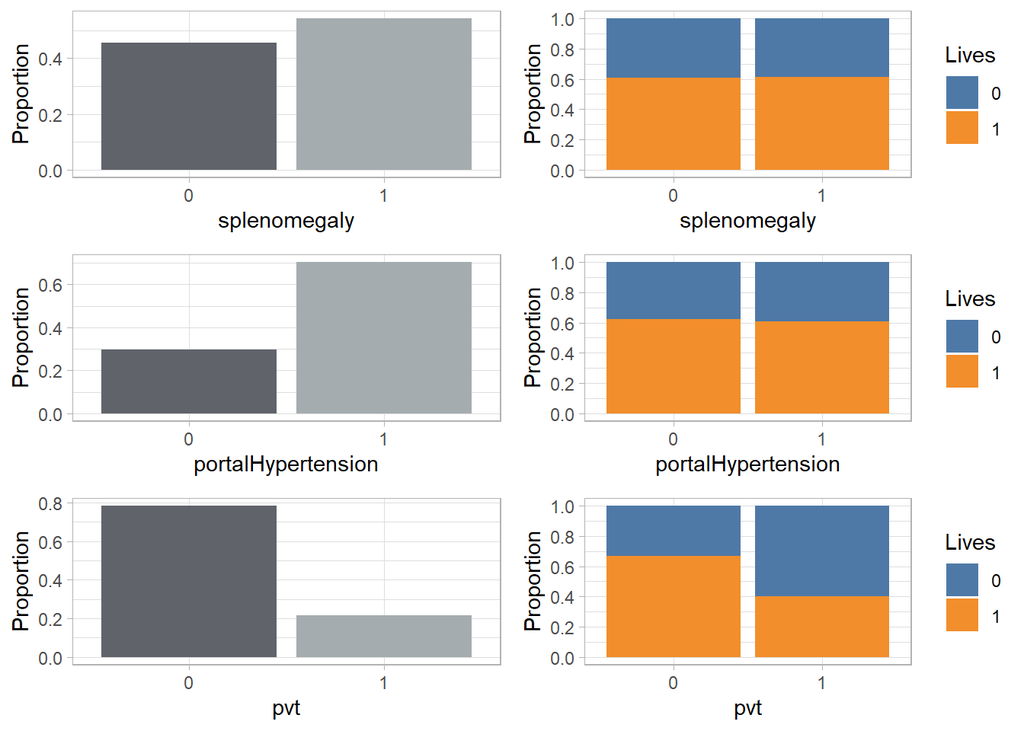

```r
cowplot::plot_grid(plots.univar[["splenomegaly"]], plots.bivar[["splenomegaly"]],
                   plots.univar[["portalHypertension"]], plots.bivar[["portalHypertension"]],
                   plots.univar[["pvt"]], plots.bivar[["pvt"]],
                   ncol = 2, axis = "tb", align = "v")
```

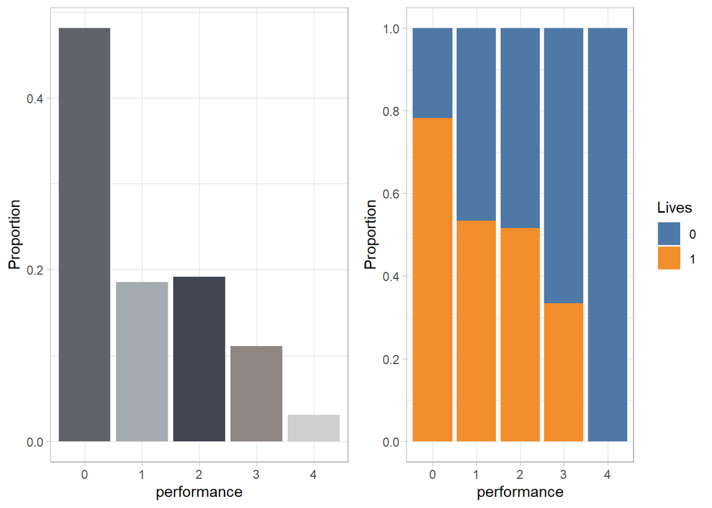

```r
# Plot performance status
cowplot::plot_grid(plots.univar[["performance"]], plots.bivar[["performance"]],
                   ncol = 2, axis = "tb", align = "v")
```

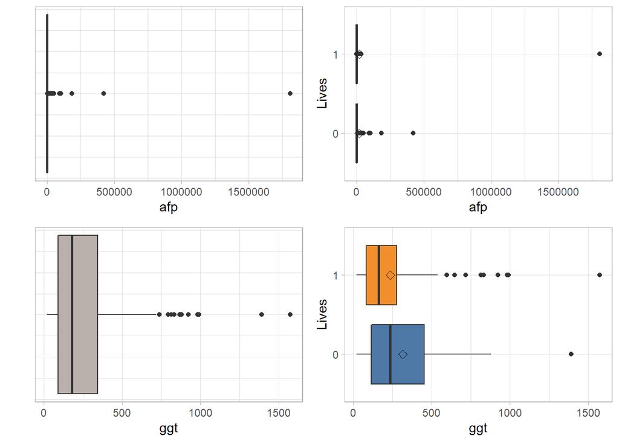

```r
# Plot molecular biomarkers
cowplot::plot_grid(plots.univar[["afp"]], plots.bivar[["afp"]],
                   plots.univar[["ggt"]], plots.bivar[["ggt"]],
                   ncol = 2, axis = "tb", align = "v")
```